# The most horrable disaster in US

Lee Chun Wai

22 June, 2014

# Synopsis

In this report we aim to describe the type of weather events that are 1) most harmful with respect to population health in the United States and 2) most costly to the United States with respect to economic consequences. Using storm data from the U.S. National Oceanic and Atmospheric Administration (NOAA), we measured population health by the number of fatalities and injuries caused and economic consequences by the dollar amount damage done to property and crops. As observed from 1950-2011, we determined the following:

- **Tornadoes** were most harmful to population health, causing about 97,000 counts of fatalities and injuries.
- **Floods** were most harmful to the economy, causing over 150 billion dollars in damage to property and crops.

# Data Processing

### Download Data

```r
dir.create("data", showWarnings = FALSE)

if (!file.exists("data/storm_data.csv.bz2")){
        url <- "https://d396qusza40orc.cloudfront.net/repdata%2Fdata%2FStormData.csv.bz2"
        download.file(url, "data/storm_data.csv.bz2", method = "curl")
}
```

### Load data into R

```r
storm <- read.csv(bzfile("data/storm_data.csv.bz2"),sep=",", header = TRUE)
```

Take a brief look on the data set using dim() and namaes()

```r
dim(storm)
```

```
## [1] 902297     37
```

```r
names(storm)
```

```
##  [1] "STATE__"    "BGN_DATE"   "BGN_TIME"   "TIME_ZONE"  "COUNTY"
##  [6] "COUNTYNAME" "STATE"      "EVTYPE"     "BGN_RANGE"  "BGN_AZI"
## [11] "BGN_LOCATI" "END_DATE"   "END_TIME"   "COUNTY_END" "COUNTYENDN"
## [16] "END_RANGE"  "END_AZI"    "END_LOCATI" "LENGTH"     "WIDTH"
## [21] "F"          "MAG"        "FATALITIES" "INJURIES"   "PROPDMG"
## [26] "PROPDMGEXP" "CROPDMG"    "CROPDMGEXP" "WFO"        "STATEOFFIC"
## [31] "ZONENAMES"  "LATITUDE"   "LONGITUDE"  "LATITUDE_E" "LONGITUDE_"
## [36] "REMARKS"    "REFNUM"
```

From the data set, we have 902297 observations and 37 columns. We only interested on a few columns below:  
* **EVTYPE** : Type of the weather. *E.g. Tornado, Flood, Draught, Storm*  
* **INJURIES** : Consist of direct/indirect injuries.  
* **FATALITIES** : Consist of direct/indirect fatalities.  
* **PROPDMG** : Property damage.  
* **PROPDMGEXP** : Exponent value for property damage. *E.g. K represent Thousand, 5 represent 10^5, etc.*  
* **CROPDMG** : Crops/Agricultural product damage.  
* **CROPDMGEXP** : Exponent value for crop damage. *E.g. K represent Thousand, 5 represent 10^5, etc.*

### Cleaning **EVTYPE** variable

We are interested in the `EVTYPE` variable which gives us the weather event responsible for the damage. The code below create a subset of the **Storm** data, and perform minor cleaning for the values in `EVTYPE` variable.

```r
subStorm = subset(storm,select = c("EVTYPE","INJURIES","FATALITIES","PROPDMG","PROPDMGEXP","CROPDMG","CROPDMGEXP"))
subStorm$EVTYPE = toupper(subStorm$EVTYPE)
subStorm$PROPDMGEXP = toupper(subStorm$PROPDMGEXP)
subStorm$CROPDMGEXP = toupper(subStorm$CROPDMGEXP)
subStorm$CHECKSUM = subStorm$INJURIES + subStorm$FATALITIES + subStorm$PROPDMG + subStorm$CROPDMG
subStorm = subset(subStorm,CHECKSUM>0 )

subStorm[grep("RIP CURRENTS",subStorm$EVTYPE),]$EVTYPE <- "RIP CURRENT";

subStorm[grep("TORNADO",subStorm$EVTYPE),]$EVTYPE <- "TORNADO";
subStorm[grep("TORNDAO",subStorm$EVTYPE),]$EVTYPE <- "TORNADO";

subStorm[subStorm$EVTYPE=="FLOOD & HEAVY RAIN",]$EVTYPE <- "FLOOD";
subStorm[subStorm$EVTYPE=="FLOODING",]$EVTYPE <- "FLOOD";
subStorm[subStorm$EVTYPE=="FLOOD/RAIN/WINDS",]$EVTYPE <- "FLOOD";
subStorm[subStorm$EVTYPE=="FLOODS",]$EVTYPE <- "FLOOD";
subStorm[subStorm$EVTYPE=="FLOOD/RIVER FLOOD",]$EVTYPE <- "FLOOD";
subStorm[subStorm$EVTYPE=="FLOODING/HEAVY RAIN",]$EVTYPE <- "FLOOD";

subStorm[grep("FLASH FLOOD",subStorm$EVTYPE),]$EVTYPE <- "FLASH FLOOD";
subStorm[subStorm$EVTYPE=="FLOOD FLASH",]$EVTYPE <- "FLASH FLOOD";
subStorm[subStorm$EVTYPE=="FLOOD/FLASH",]$EVTYPE <- "FLASH FLOOD";
subStorm[subStorm$EVTYPE=="FLOOD/FLASH/FLOOD",]$EVTYPE <- "FLASH FLOOD";
subStorm[subStorm$EVTYPE=="FLOOD/FLASHFLOOD",]$EVTYPE <- "FLASH FLOOD";
subStorm[subStorm$EVTYPE=="RIVER FLOOD",]$EVTYPE <- "FLASH FLOOD";

subStorm[subStorm$EVTYPE=="HEAT WAVE",]$EVTYPE <- "HEAT";
subStorm[subStorm$EVTYPE=="HEAT WAVES",]$EVTYPE <- "HEAT";
subStorm[subStorm$EVTYPE=="HEAT WAVE DROUGHT",]$EVTYPE <- "HEAT";

subStorm[grep("HURRICANE",subStorm$EVTYPE),]$EVTYPE <- "HURRICANE/TYPHOON";
subStorm[grep("TYPHOON",subStorm$EVTYPE),]$EVTYPE <- "HURRICANE/TYPHOON";

subStorm[grep("LIGHTNING",subStorm$EVTYPE),]$EVTYPE <- "LIGHTNING";
subStorm[subStorm$EVTYPE=="LIGNTNING",]$EVTYPE  <- "LIGHTNING";
subStorm[subStorm$EVTYPE=="LIGHTING",]$EVTYPE  <- "LIGHTNING";

subStorm[grep("THUNDERSTORM",subStorm$EVTYPE),]$EVTYPE <- "THUNDERSTORM WIND";
subStorm[grep("TSTM WIND",subStorm$EVTYPE),]$EVTYPE <- "THUNDERSTORM WIND";
subStorm[subStorm$EVTYPE=="THUDERSTORM WINDS",]$EVTYPE  <- "THUNDERSTORM WIND";
subStorm[subStorm$EVTYPE=="THUNERSTORM WINDS",]$EVTYPE  <- "THUNDERSTORM WIND";
subStorm[subStorm$EVTYPE=="THUNDERTORM WINDS",]$EVTYPE  <- "THUNDERSTORM WIND";
subStorm[subStorm$EVTYPE=="THUNDERESTORM WINDS",]$EVTYPE  <- "THUNDERSTORM WIND";
subStorm[subStorm$EVTYPE=="THUNDERSTROM WIND",]$EVTYPE  <- "THUNDERSTORM WIND";
subStorm[subStorm$EVTYPE=="THUNDEERSTORM WINDS",]$EVTYPE  <- "THUNDERSTORM WIND";
subStorm[subStorm$EVTYPE=="TSTMW",]$EVTYPE  <- "THUNDERSTORM WIND";
subStorm[subStorm$EVTYPE=="TUNDERSTORM WIND",]$EVTYPE  <- "THUNDERSTORM WIND";

rm(storm)
```

### Standardizing PROPDMGEXP and CROPDMGEXP variables

*We are tranforming the undefined or invalid value by assuming the losses from the impact of natural disasters are not less than a thousand.*

```r
subStorm[subStorm$PROPDMGEXP=="H",]$PROPDMGEXP  <- "2";
subStorm[subStorm$PROPDMGEXP=="K",]$PROPDMGEXP  <- "3";
subStorm[subStorm$PROPDMGEXP=="M",]$PROPDMGEXP  <- "6";
subStorm[subStorm$PROPDMGEXP=="B",]$PROPDMGEXP  <- "9";
subStorm[subStorm$PROPDMGEXP=="+",]$PROPDMGEXP  <- "3";
subStorm[subStorm$PROPDMGEXP=="-",]$PROPDMGEXP  <- "3";
subStorm[subStorm$PROPDMGEXP=="0",]$PROPDMGEXP  <- "3";
subStorm[subStorm$PROPDMGEXP=="",]$PROPDMGEXP  <- "3";
subStorm$PROPDMGEXP = as.numeric(subStorm$PROPDMGEXP)

subStorm[subStorm$CROPDMGEXP=="K",]$CROPDMGEXP  <- "3";
subStorm[subStorm$CROPDMGEXP=="M",]$CROPDMGEXP  <- "6";
subStorm[subStorm$CROPDMGEXP=="B",]$CROPDMGEXP  <- "9";
subStorm[subStorm$CROPDMGEXP=="0",]$CROPDMGEXP  <- "3";
subStorm[subStorm$CROPDMGEXP=="?",]$CROPDMGEXP  <- "3";
subStorm[subStorm$CROPDMGEXP=="",]$CROPDMGEXP  <- "3";
subStorm$CROPDMGEXP = as.numeric(subStorm$CROPDMGEXP)
```

### Calculate the total impact on population Health

To assess harm to population health, we will be using the `FATALITIES` and `INJURIES` variables.  
Missing values are dropped from the analysis by default.

```r
library(reshape2)
popImpacts <- aggregate(cbind(FATALITIES,INJURIES) ~ EVTYPE, data = subStorm, sum)
topInjury = head(popImpacts[order(popImpacts$INJURIES,decreasing=TRUE),],8)
topFatal= head(popImpacts[order(popImpacts$FATALITIES,decreasing=TRUE),],8)
casualties = rbind(topInjury,topFatal)
casualties = unique(casualties)
m.casualties = melt(casualties, id.vars="EVTYPE", value.name="incident",variable.name = "type",)
```

Now that we have variables to represent economic consequences with the appropriate magnitude we can apply a similar approach as we did with population health to aggregate the cost data by EVTYPE.

### Calculate the total impact on economy

```r
library(reshape2)
econImpacts <- aggregate(cbind((CROPDMG*10^CROPDMGEXP),(PROPDMG*10^PROPDMGEXP)) ~ EVTYPE, data = subStorm, sum)
names(econImpacts) = c("EVTYPE","CROPDAMAGE","PROPDAMAGE")
topProp = head(econImpacts[order(econImpacts$PROPDAMAGE,decreasing=TRUE),],8)
topCrop= head(econImpacts[order(econImpacts$CROPDAMAGE,decreasing=TRUE),],8)
losses = rbind(topProp,topCrop)
losses = unique(losses)
m.losses = melt(losses, id.vars="EVTYPE", value.name="Figures",variable.name = "type",)
```

# Results

### Impact to Population Health

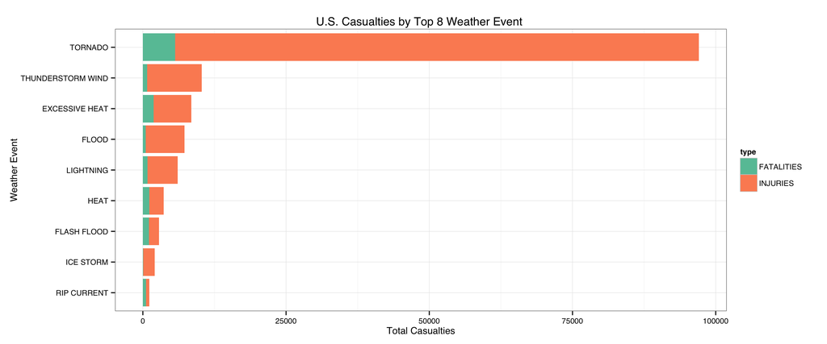

```r
library(ggplot2)
ggplot(m.casualties, aes(x=reorder(EVTYPE,incident), y=incident, fill=type)) +
        geom_bar( stat="identity") +
        coord_flip() +
        ggtitle("U.S. Casualties by Top 8 Weather Event ") +
        xlab("Weather Event") +
        ylab("Total Casualties") +
        theme_bw(base_size = 10, base_family = "Helvetica") +
        scale_fill_brewer(palette="Set2")
```

From 1950-2011 in the United States, `tornadoes` by far cause the most harm to population health with respect to fatalities and injuries caused at 9.7068 × 10<sup>4</sup> people.

### Impact to Economy

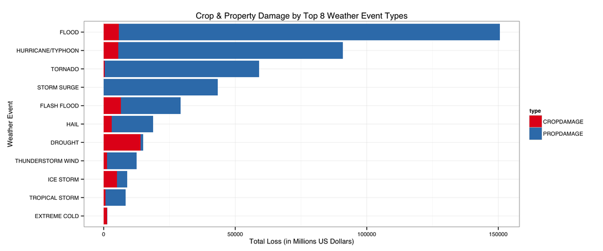

```r
ggplot(m.losses, aes(x=reorder(EVTYPE,Figures), y=Figures/10^6, fill=type)) +
        geom_bar( stat="identity") +
        coord_flip() +
        ggtitle("Crop & Property Damage by Top 8 Weather Event Types") +
        xlab("Weather Event") +
        ylab("Total Loss (in Millions US Dollars)") +
        theme_bw(base_size = 10, base_family = "Helvetica") +
        scale_fill_brewer(palette="Set1")
```

From 1950-2011 in the United States, `floods` cause the most economic damage with respect to damage to property and crops at $150.5667 billion dollar.